# Project #4

[figure not shown]

[figure not shown]

[figure not shown]

[figure not shown]

[figure not shown]

[figure not shown]

[figure not shown]

[figure not shown]

[figure not shown]

# Quant Regression and Autoplots of Returns and Size

### Nickel and Copper Quantile Regression

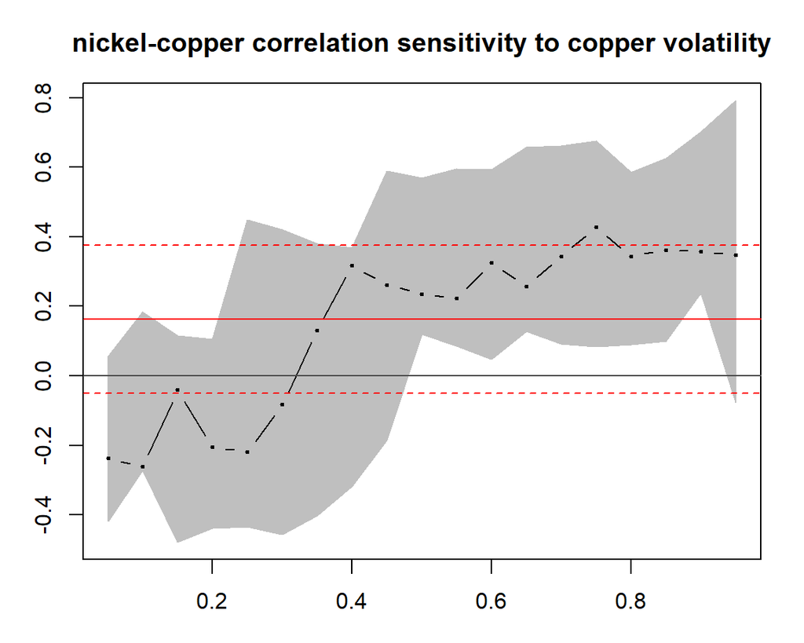

### Chart information

The chart above shows the results of a quantile regression with the monthly correlation computed using the apply.monthly function acting as our dependent variable, while the monthly standard deviation of copper is acting as our independent variable. Quantile regression is important because we are not always concerned with the conditional mean, and as such we could look at the quantile ranges of our independent variable(s) and the resulting relationship with our dependent variable. This method is also preferred when we have nonconstant variance, and a straight line through our data may not fit well through variance, for example, when x is closer to 0, but as we move along the axis, there is growth in error/residuals. In the case of our RQ fit here, we can see breaks of the lower bound until x=.3, and a slight break around .8.

### Quantile Regression Summary

```
Call: rq(formula = nickel.corrs ~ copper.vols, tau = taus)

tau: [1] 0.05

Coefficients:
            Value    Std. Error t value  Pr(>|t|)
(Intercept) -0.02592  0.14209   -0.18244  0.85585
copper.vols -0.23752  0.14564   -1.63091  0.10806

Call: rq(formula = nickel.corrs ~ copper.vols, tau = taus)

tau: [1] 0.1

Coefficients:
            Value    Std. Error t value  Pr(>|t|)
(Intercept)  0.01589  0.19457    0.08166  0.93519
copper.vols -0.26180  0.17924   -1.46059  0.14926

Call: rq(formula = nickel.corrs ~ copper.vols, tau = taus)

tau: [1] 0.15

Coefficients:
            Value    Std. Error t value  Pr(>|t|)
(Intercept) -0.13476  0.23112   -0.58305  0.56201
copper.vols -0.04067  0.19378   -0.20990  0.83445

Call: rq(formula = nickel.corrs ~ copper.vols, tau = taus)

tau: [1] 0.2

Coefficients:
            Value    Std. Error t value  Pr(>|t|)
(Intercept)  0.11323  0.27351    0.41397  0.68035
copper.vols -0.20463  0.25948   -0.78862  0.43339

Call: rq(formula = nickel.corrs ~ copper.vols, tau = taus)

tau: [1] 0.25

Coefficients:
            Value    Std. Error t value  Pr(>|t|)
(Intercept)  0.18765  0.28783    0.65195  0.51688
copper.vols -0.21889  0.28479   -0.76862  0.44508

Call: rq(formula = nickel.corrs ~ copper.vols, tau = taus)

tau: [1] 0.3

Coefficients:
            Value    Std. Error t value  Pr(>|t|)
(Intercept)  0.11107  0.30863    0.35988  0.72018
copper.vols -0.08287  0.32015   -0.25884  0.79663

Call: rq(formula = nickel.corrs ~ copper.vols, tau = taus)

tau: [1] 0.35

Coefficients:
            Value    Std. Error t value  Pr(>|t|)
(Intercept) -0.03072  0.29811   -0.10304  0.91827
copper.vols  0.13058  0.31667    0.41236  0.68152

Call: rq(formula = nickel.corrs ~ copper.vols, tau = taus)

tau: [1] 0.4

Coefficients:
            Value    Std. Error t value  Pr(>|t|)
(Intercept) -0.15415  0.24877   -0.61964  0.53780
copper.vols  0.31640  0.27826    1.13707  0.25996

Call: rq(formula = nickel.corrs ~ copper.vols, tau = taus)

tau: [1] 0.45

Coefficients:
            Value    Std. Error t value  Pr(>|t|)
(Intercept) -0.00536  0.21559   -0.02487  0.98024
copper.vols  0.26201  0.22896    1.14433  0.25696

Call: rq(formula = nickel.corrs ~ copper.vols, tau = taus)

tau: [1] 0.5

Coefficients:
            Value   Std. Error t value Pr(>|t|)
(Intercept) 0.08028 0.23790    0.33748 0.73692
copper.vols 0.23573 0.24593    0.95856 0.34157

Call: rq(formula = nickel.corrs ~ copper.vols, tau = taus)

tau: [1] 0.55

Coefficients:
            Value   Std. Error t value Pr(>|t|)
(Intercept) 0.16267 0.16509    0.98536 0.32834
copper.vols 0.22255 0.16121    1.38045 0.17248

Call: rq(formula = nickel.corrs ~ copper.vols, tau = taus)

tau: [1] 0.6

Coefficients:
            Value   Std. Error t value Pr(>|t|)
(Intercept) 0.11750 0.19712    0.59606 0.55334
copper.vols 0.32493 0.19098    1.70137 0.09397

Call: rq(formula = nickel.corrs ~ copper.vols, tau = taus)

tau: [1] 0.65

Coefficients:
            Value   Std. Error t value Pr(>|t|)
(Intercept) 0.23206 0.20172    1.15041 0.25446
copper.vols 0.25807 0.18208    1.41736 0.16147

Call: rq(formula = nickel.corrs ~ copper.vols, tau = taus)

tau: [1] 0.7

Coefficients:
            Value   Std. Error t value Pr(>|t|)
(Intercept) 0.17401 0.19928    0.87323 0.38596
copper.vols 0.34402 0.17651    1.94908 0.05589

Call: rq(formula = nickel.corrs ~ copper.vols, tau = taus)

tau: [1] 0.75

Coefficients:
            Value   Std. Error t value Pr(>|t|)
(Intercept) 0.12753 0.21158    0.60273 0.54892
copper.vols 0.42702 0.18614    2.29402 0.02525

Call: rq(formula = nickel.corrs ~ copper.vols, tau = taus)

tau: [1] 0.8

Coefficients:
            Value   Std. Error t value Pr(>|t|)
(Intercept) 0.24919 0.17445    1.42841 0.15827
copper.vols 0.34367 0.15267    2.25101 0.02800

Call: rq(formula = nickel.corrs ~ copper.vols, tau = taus)

tau: [1] 0.85

Coefficients:
            Value   Std. Error t value Pr(>|t|)
(Intercept) 0.26383 0.14212    1.85639 0.06823
copper.vols 0.36193 0.12885    2.80888 0.00667

Call: rq(formula = nickel.corrs ~ copper.vols, tau = taus)

tau: [1] 0.9

Coefficients:
            Value   Std. Error t value Pr(>|t|)
(Intercept) 0.29497 0.11850    2.48922 0.01555
copper.vols 0.35664 0.11090    3.21590 0.00208

Call: rq(formula = nickel.corrs ~ copper.vols, tau = taus)

tau: [1] 0.95

Coefficients:
            Value   Std. Error t value Pr(>|t|)
(Intercept) 0.32766 0.11384    2.87829 0.00551
copper.vols 0.34688 0.11144    3.11258 0.00282
```

### Correlation/Scatterplots of volatility across the three metals

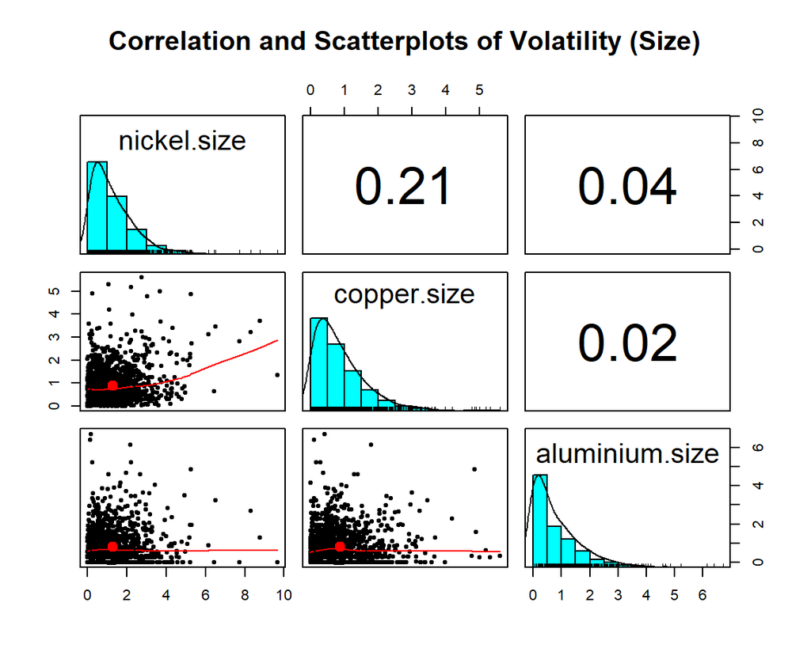

### Chart information

The chart above shows correlation in regards to size/volatility of the 3 metals. The directionality and the volatility is non-relational across the three sets of observations, suggesting that movement doesn’t occur in synchrony.

The chart on the right is showing movement in returns, taking the first three columns which are derived from the log difference of the initial values * 100. The resulting graphs appear to show a level of stationarity, meaning that the mean and the variance appear to be constant over time- Movement in one direction generally appears to be counteracted with a similar move in the opposite direction, rendering a mean return somewhere around zero throughout the time series. Stationarity also helps to show us if our data has trends, or seasonality involved, which in this setting does not appear to be the case.

It is also showing size, or columns 4:6 of our dataframe, and is showing the absolute values of the previous three columns. Plotting size helps us to look at volatility without regard to directionality. The charts show that Nickel appears to be the most volatile of the metals, judging by density and mean.

### Metals Market Movements

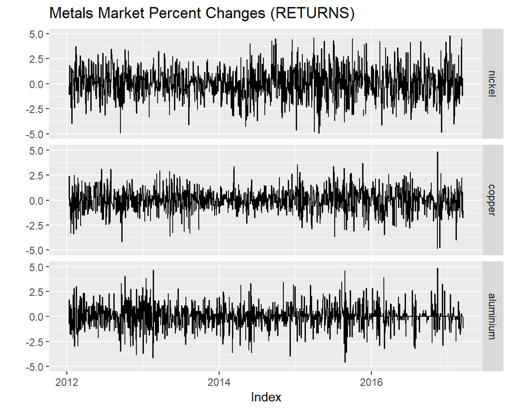

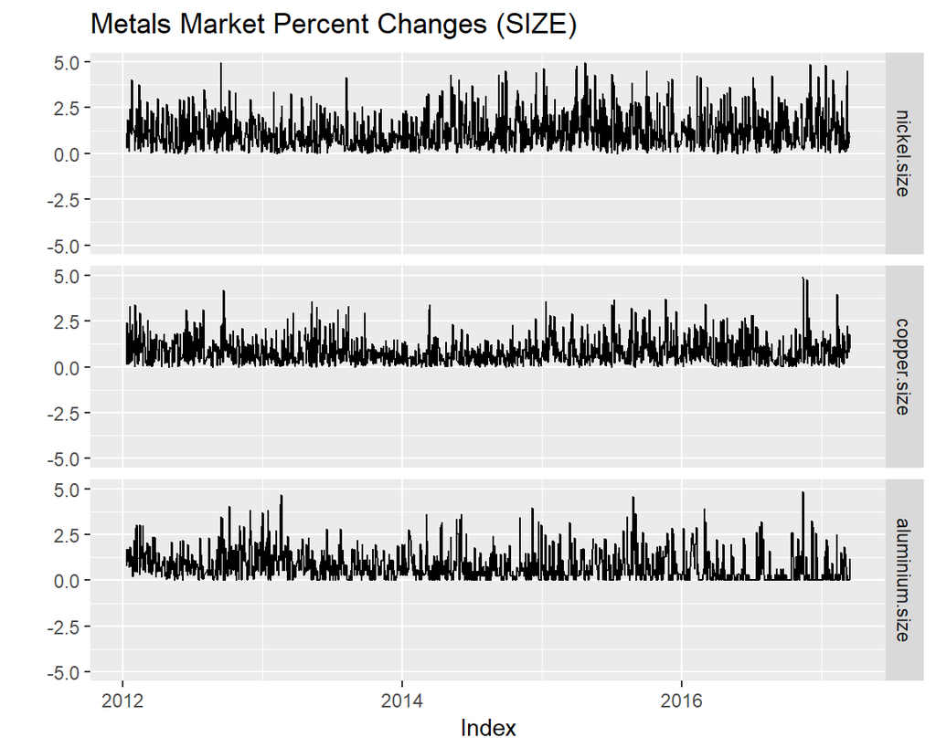

# ACF and PCF

### Autocorrelation (Returns+Sizes)

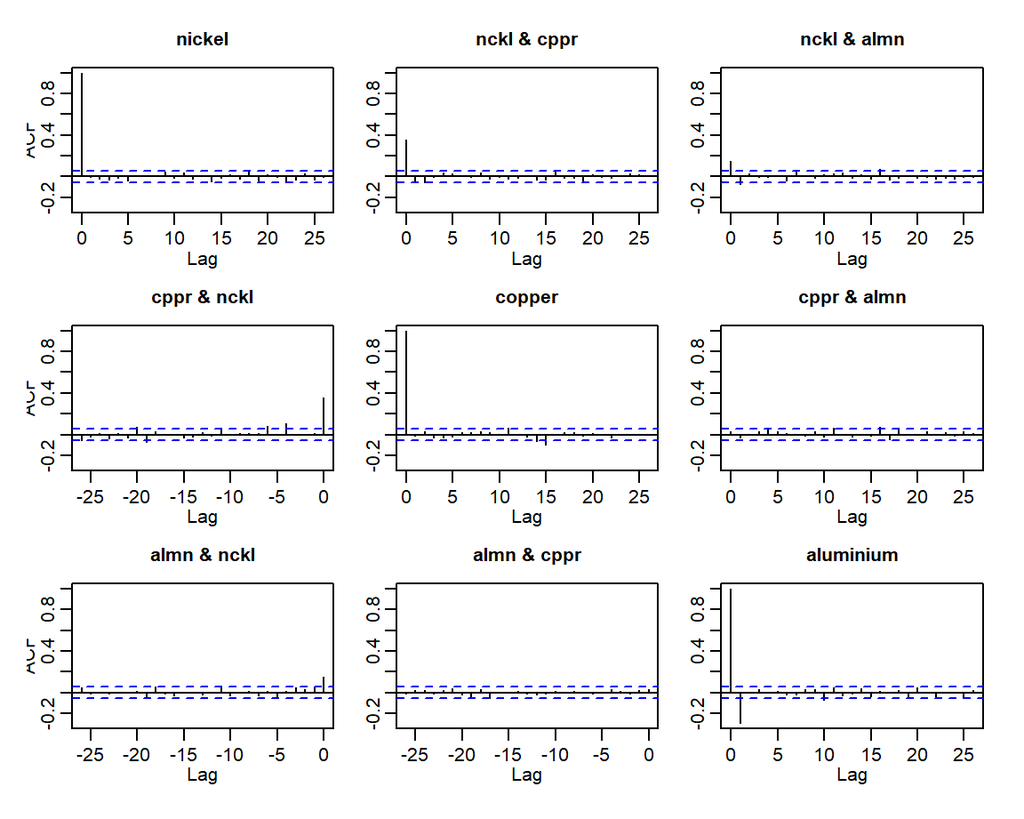

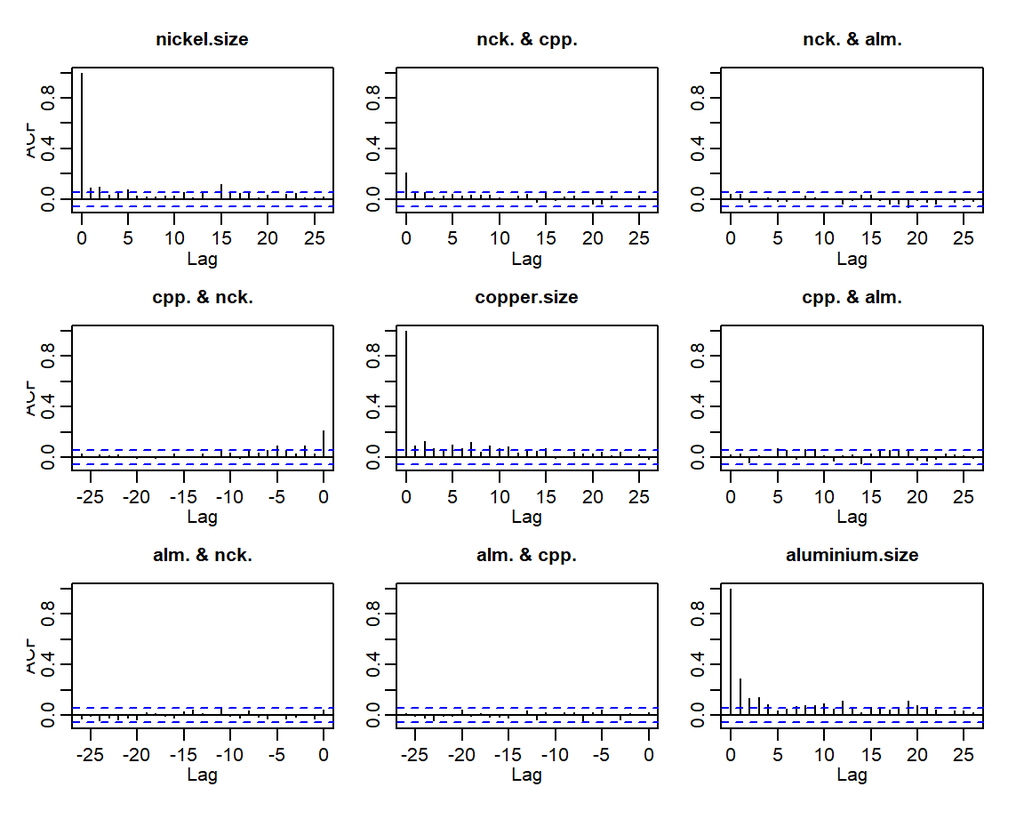

### About these charts

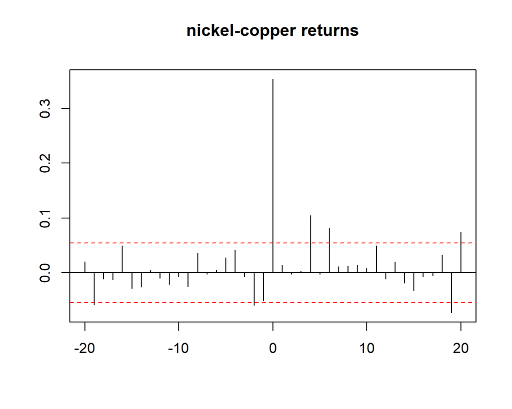

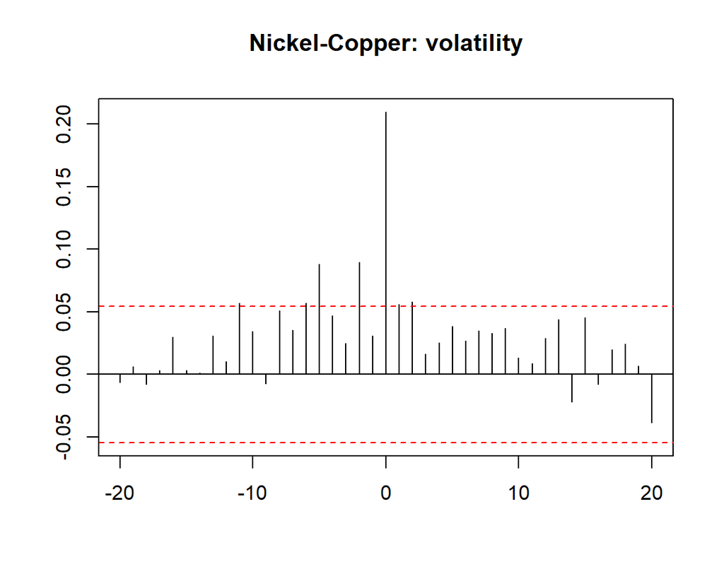

# Data Moments

### Data Moments

|  | mean | median | std_dev | IQR | skewness | kurtosis |
| --- | --- | --- | --- | --- | --- | --- |
| nickel | 0.0489 | 0.0928 | 1.7072 | 2.0479 | 0.1932 | 5.2688 |
| copper | 0.0200 | 0.0595 | 1.1815 | 1.3508 | -0.2010 | 4.8894 |
| aluminium | 0.0149 | 0.0000 | 1.2080 | 1.0672 | -0.1557 | 6.3417 |
| nickel.size | 1.2830 | 1.0257 | 1.1268 | 1.3496 | 1.9210 | 9.6851 |
| copper.size | 0.8830 | 0.6823 | 0.7849 | 0.9217 | 1.7713 | 7.8654 |
| aluminium.size | 0.8072 | 0.5510 | 0.8986 | 1.0136 | 1.8899 | 8.4006 |
| nickel.dir | 0.0447 | 1.0000 | 0.9959 | 2.0000 | -0.0895 | 1.0150 |
| copper.dir | 0.0540 | 1.0000 | 0.9931 | 2.0000 | -0.1081 | 1.0235 |
| aluminium.dir | 0.0455 | 0.0000 | 0.8706 | 2.0000 | -0.0879 | 1.3259 |

### Histograms of Returns and Sizes

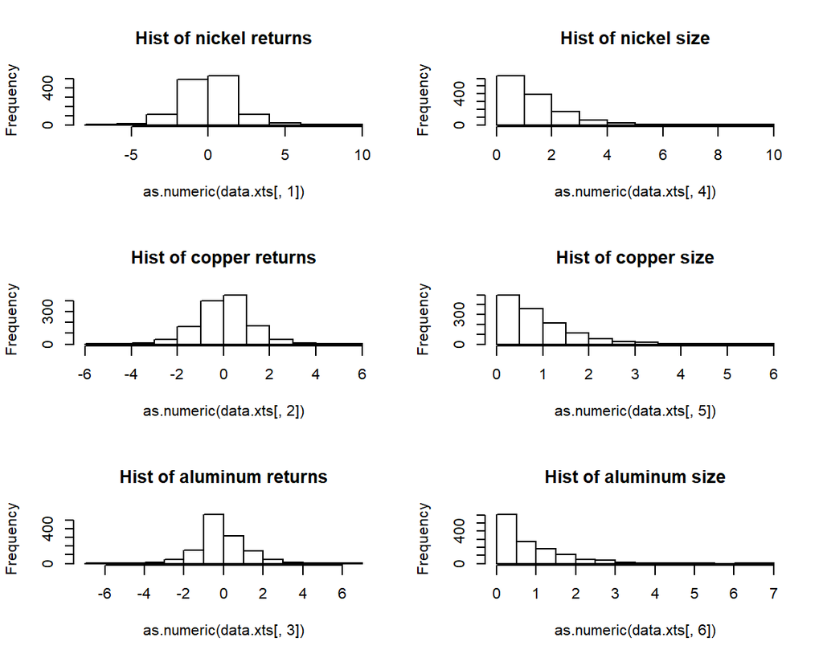

# Expected Shortfall & VaR/ Loss Analysis / Extreme Event Management

### Expected Shortfall & VaR

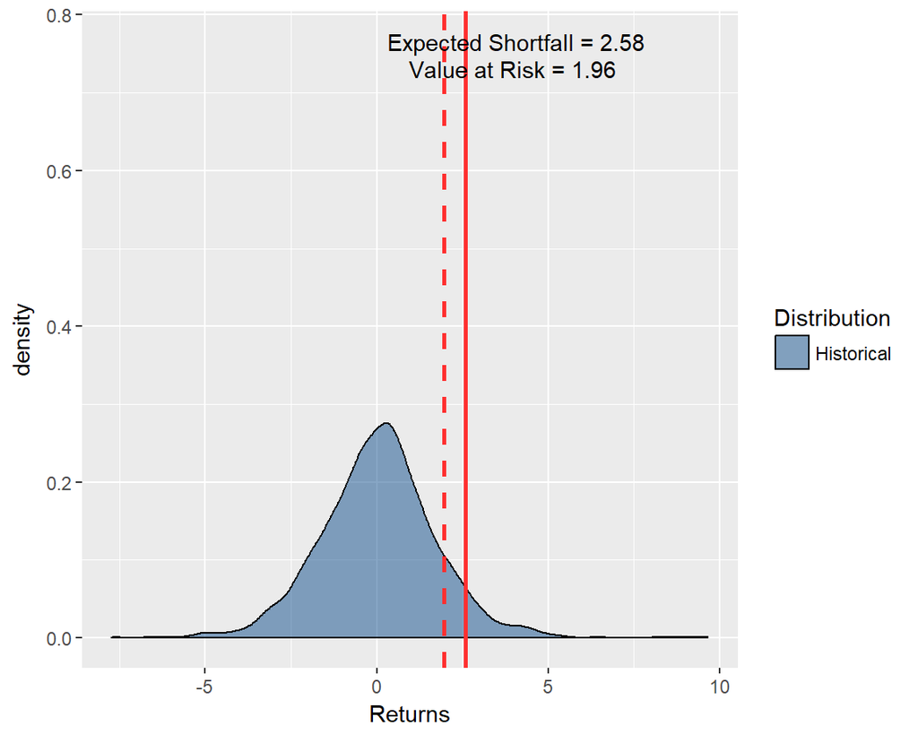

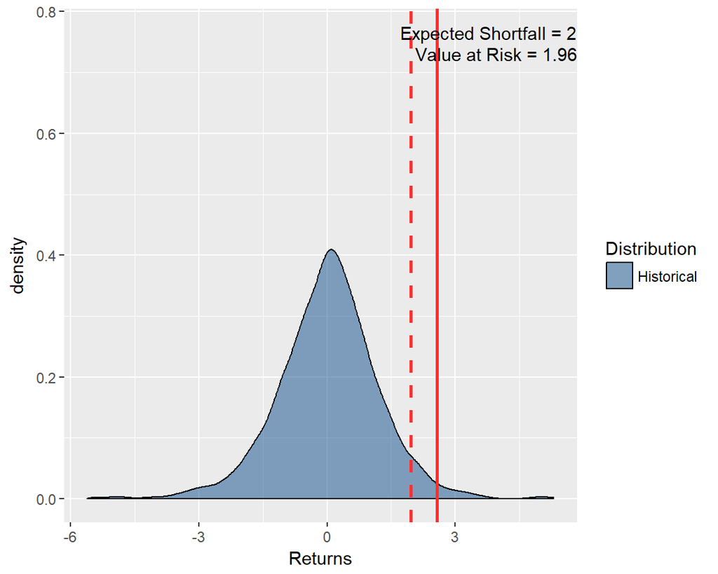

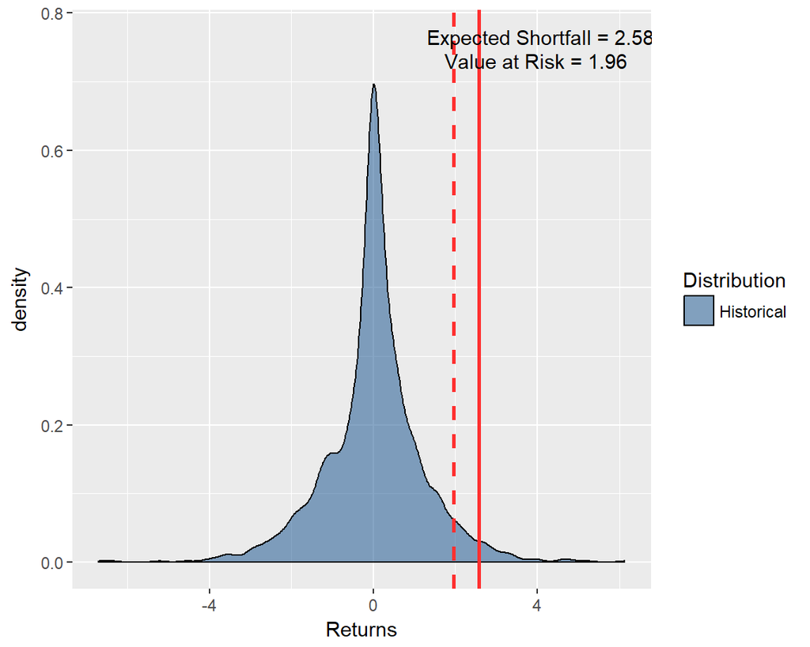

### Loss Analysis

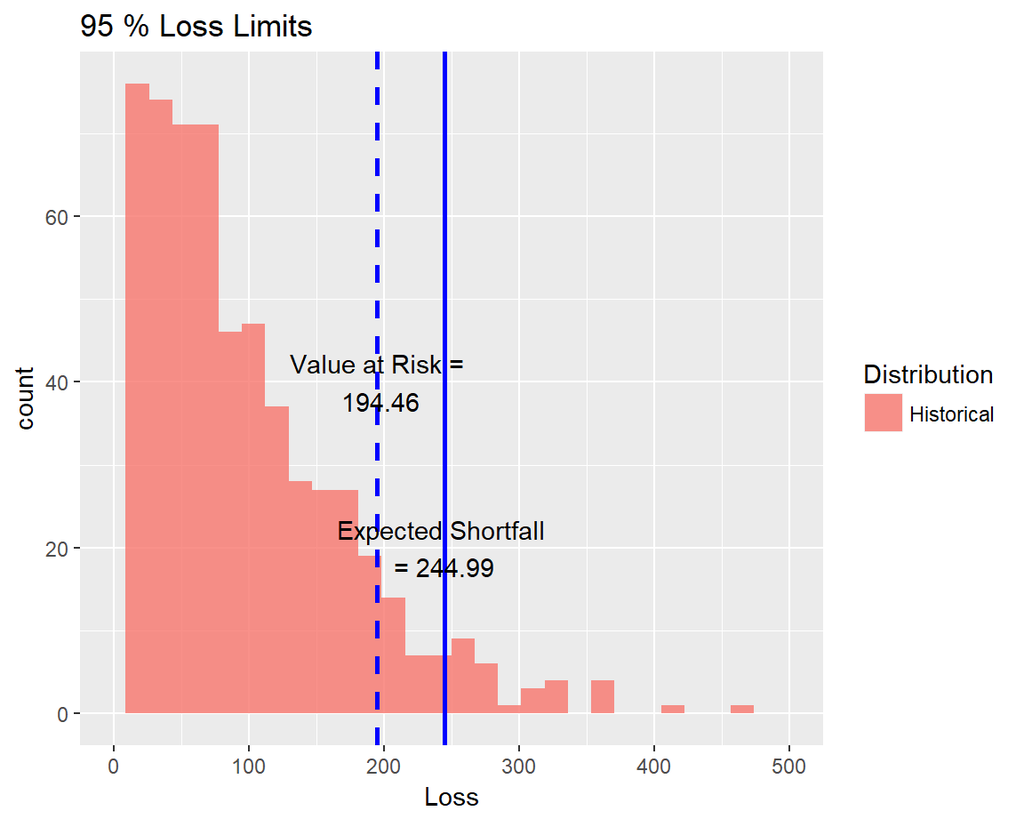

### About the data

We used this data above to calculate the losses attributable to the metal risk factors by using the log price relative. First we had to calculate the returns by using a weight factor for each metal by defining the last notional price. After applying the weight factor we can calculate the share price and number of shares. There will be a naturally short position and a naturally long position. The naturally short is usually the demand while the naturally long is the revenue earned. The graph revelas that there the expected shortfall is around 2.5 and VAR at 1.96. There is not much of a gap between the ES and the VAR. Using the VAR is useful because it provides insight on what the potential impact of a price change.

### Extreme Event Management

```
$title
[1] "GPD: Value at Risk = 365.31 Expected Shortfall = 450.49"

$subtitle
NULL

attr(,"class")
[1] "labels"
```

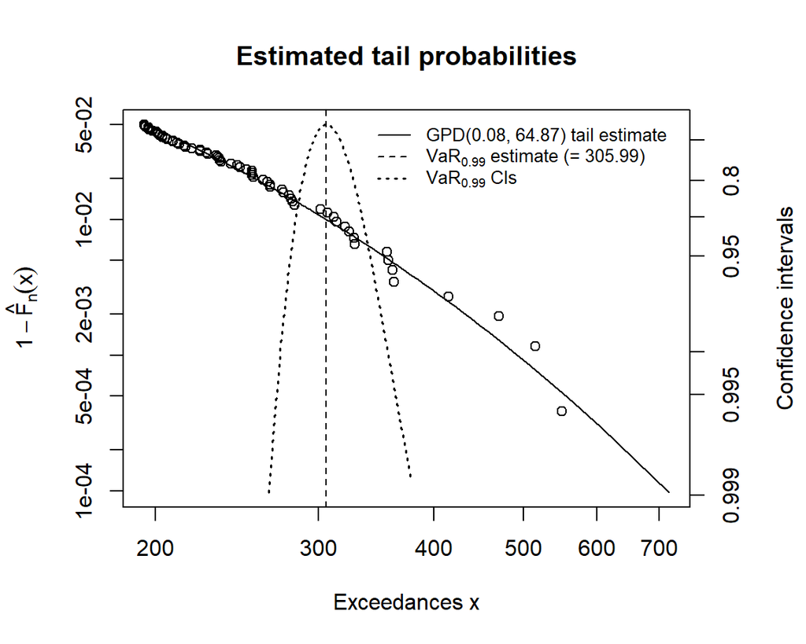

# Business Questions

### Skills Used and Data Insights

This was our foray into flexdashboard, which produces a series of charts and texts rendered in an HTML UI for cleaner consumption and flow of analysis. We did not utilize the shiny library, which produces interactive charts, but will utilize it on our final project (manipulatable sliders, etc..). Data cleansing techniques and data transformations follow the structure of projects 1:3 and include logdiffs, absolute values of logdiffs, and various datatype transformation using the zooreg and ts functions. We used ggplot2 and base R visualizations techniques, along with ACF, PACF, CCF correlelograms throughout this assignment to display depictions of price movements, distributions, and relationships of the metals over time. The Psych library was used to show correlation amongst our three metals in regards to various attributes. User defined functions include: corr.rolling for rolling correlation, data moments for stylized facts of the market and distributions of each of our attributes w/ knitr being used to render cleaner charts. We also used the quantile regression function to construct a model not reliant on the conditional mean of our dependent variable. We create ggplots depicting Value at Risk and Expected Shortfall for the returns of each metal to help us to understand market risk of a portfolio. Expected shortfall helps to show expected return on the tail end of distributions. Value at Risk is not as sensitive to extreme tails and attempts to simulate loss assuming normal market conditions.

### Key business questions

1. How would the performance of these commodities affect the size and timing of shipping arrangements?

As with any commodity, there is a commodity risk. Business performance may be negatively impacted by the fluctuation of the price. If there is a price drop, the company will receive less revenue. There could potentially be a quantity risk which would impact the availability of the product. If the product is not available then it can’t be shipped or it may be delayed which is a result of the time lag between the order and receipt of goods. The stationarity of the returns of the three metals over the past 5 years would seemingly mitigate, over time, any potential losses due to temporal trends. It is of note, however, that of the three metals analyzed here, nickel appears to be the most volatile.

2. How would the value of new shipping arrangements affect the value of our business with our current customers?

It would vary based on the different production and shipping contracts. Typically producers and buyers have contracts that would specifiy the inputs to be supplied to the buyer, the quantity of the metal, the delivery of the metal, and the also the price paid. The buyer typically has a higher degree of uncertaintly about forecasting future revenue.

3. How would we manage the allocation of existing resources given we have just landed in this new market?

One way of managing the allocation would be to understand strategic risk management. The first successful approach would be to diversify the most common metals which would reduce the risk and uncertainty. Diversification can be effective when the producer has an alternate production that is not subject to just a volatile price market. If that’s not an option, they need to be aware that significant costs may be incurred while reducing efficiencies.

### Getting to a reponse: more detailed questions

4. What is the decision the freight-forwarder must make? List key business questions and data needed to help answer these questions and support the freight-forwarder’s decision. The freight fowarder must decide if they should enter the tramp trade. This means they must have vessels and vessel operations personnel available on short notice. They have allowed for a reserve of capital (250M) to meet the need of a last minute deployment of our shipping resources. The company should consider the following questions:
1. What is out exppected revenue/loss?
2. If a loss is generated, what is the potential frequency and severity?
3. What is the potential operational risk?
4. What events could happen to impact the shipments and prices?
5. Who are the domestic vs. international customers?
6. How can we efficently quote freight costs? If customers are mainly international, consider the international border laws and transport delays. Customs procedures can be extremely complicated and inconsistent from country to country. These procedures may need to addressed on an individual customer basis.
5. Develop the stylized facts of the markets the freight-forwarder faces. Include level, returns, size times series plots. Calculate and display in a table the summary statistics, including quantiles, of each of these series. Use autocorrelation, partial autocorrelation, and cross correlation functions to understand some of the persistence of returns including leverage and volatility clustering effects. Use quantile regressions to develop the distribution of sensitivity of each market to spill-over effects from other markets. Interpret these stylized “facts” in terms of the business decision the freight-forwarder makes.

Please refer to the quantile regression tab for facts and analysis.

6. How much capital would the freight-forwarder need? Determine various measures of risk in the tail of each metal’s distribution. Then figure out a loss function to develop the portfolio of risk, and the determination of risk capital the freight-forwarder might need. Confidence intervals might be used to create a risk management plan with varying tail experience thresholds. Please refer to Expected Shortfall tab for calculations.

Our value at risk is the amount the company could lose. In this case the value at risk is 194M. With an expected shortfall of 245M we would need to have at least that amount to cover any potential losses. Typically, the amount of capital needed for would be the amount of the fixed and variable costs. Usually payment from customers is not received until the product is received or beyond depending on payment terms established when sale is confirmed. This may cause a delay in receiving funds. In this volatile market, we should modify payment terms to require customer prepayment amount or issue a letter of credit.